# LSTM-Based Next Word Prediction

### *From Raw Text to Intelligent Word Generation*

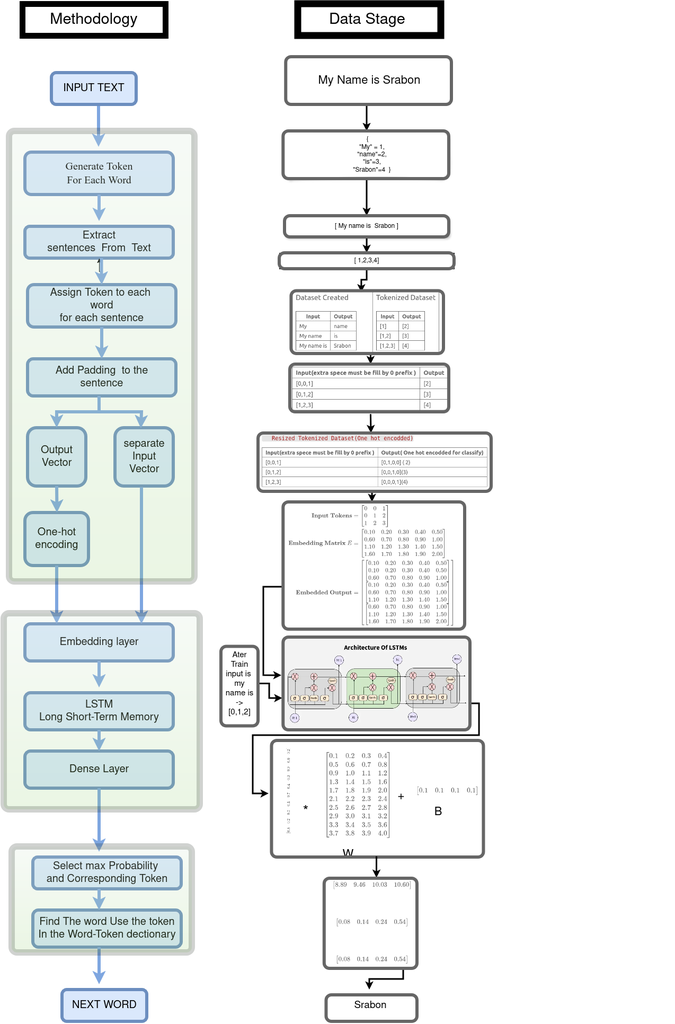

## Project Overview

This project demonstrates the complete implementation of an **LSTM (Long Short-Term Memory)** based **Next Word Prediction** model developed from scratch. Rather than only training a neural network, the notebook explains **every mathematical and preprocessing step** involved in transforming raw text into meaningful predictions.

The objective is to illustrate the entire NLP pipeline—from tokenization and sequence generation to embedding, LSTM learning, dense layer computation, probability estimation, and final word prediction.

## Methodology

The complete workflow is illustrated in the methodology diagram above.

### **1. Text Preprocessing**

- Input raw text corpus
- Extract sentences
- Generate a vocabulary
- Assign a unique integer token to every word

### **2. Sequence Generation**

- Convert each sentence into numerical token sequences
- Create multiple input-output training pairs
- Apply zero-padding to produce fixed-length input vectors

### **3. Label Encoding**

- Convert output words into **One-Hot Encoded** vectors for supervised learning.

### **4. Embedding Layer**

- Transform sparse token IDs into dense continuous vector representations.
- Learn semantic relationships between words during training.

### **5. LSTM Network**

- Process embedded sequences through LSTM cells.
- Capture contextual and long-term dependencies between words.

### **6. Dense Layer**

- Perform matrix multiplication

[ \mathbf{z}= \mathbf{h}W+b ]

where

- (h) = LSTM hidden state
- (W) = Dense layer weights
- (b) = Bias vector

### **7. Softmax Prediction**

Convert logits into probabilities

[ P(y_i)=\frac{e^{z_i}}{\sum_j e^{z_j}} ]

The token with the highest probability becomes the predicted next word.

## Pipeline Summary

```
Raw Text
    │
    ▼
Tokenization
    │
    ▼
Sequence Generation
    │
    ▼
Padding
    │
    ▼
One-Hot Encoding
    │
    ▼
Embedding Layer
    │
    ▼
LSTM
    │
    ▼
Dense Layer
    │
    ▼
Softmax
    │
    ▼
Next Word Prediction
```

## Key Learning Objectives

✔ Understand NLP preprocessing from first principles

✔ Visualize how tokenization creates numerical datasets

✔ Learn how embedding converts integers into dense vectors

✔ Understand LSTM memory flow

✔ Follow Dense layer computations mathematically

✔ Interpret Softmax probabilities for next-word prediction

## 🛠 Technologies Used

- Python
- NumPy
- TensorFlow / Keras
- LSTM
- Embedding Layer
- One-Hot Encoding
- Jupyter Notebook

```python
text=""" geeksforgeeks

    Courses
    Tutorials
    Interview Prep

    DSA
    Practice Problems
    C
    C++
    Java
    Python
    JavaScript
    Data Science
    Machine Learning
    Courses
    Linux
    DevOps

Introduction to Long Short Term Memory
Last Updated : 18 May, 2026

Long Short-Term Memory (LSTM) is an improved version of the Recurrent Neural Network (RNN) designed to capture long-term dependencies in sequential data. It uses a memory cell to store information over time, solving the limitations of traditional RNNs.

    Handles Long Term Dependencies: Remembers information for longer sequences
    Memory Cell: Stores and updates important information over time
    Better than RNN: Overcomes short term memory limitations
    Applications: Used in language translation, speech recognition and time series forecasting

introduction_to_lstms.webpintroduction_to_lstms.webp
Problem with Long-Term Dependencies in RNN

RNNs are designed to handle sequential data by using a hidden state that stores information from previous steps. However, they struggle to learn long-term dependencies. This happens due to:

    Vanishing Gradient: When training a model over time, the gradients which help the model learn can shrink as they pass through many steps. This makes it hard for the model to learn long-term patterns since earlier information becomes almost irrelevant.
    Exploding Gradient: Sometimes gradients can grow too large causing instability. This makes it difficult for the model to learn properly as the updates to the model become erratic and unpredictable.

LSTM Architecture

LSTM (Long Short-Term Memory) architecture is designed to learn long-term dependencies in sequential data using memory cells and gates that control the flow of information through the network.
Main Gates in LSTM

    Input Gate: Decides which new information should be added to the memory cell
    Forget Gate: Determines which information should be removed from the memory cell
    Output Gate: Controls which information from the memory cell is passed to the next hidden state and output

Working of LSTM

LSTM consists of a repeating chain like structure with memory cells and gating mechanisms
gate_of_lstm
LSTM Model

Information is retained by the cells and the memory manipulations are done by thegates. There are three gates:
1. Forget Gate

The forget gate decides which information should be kept or removed from the cell state. It uses the current input x_t and previous hidden state h_{t-1} then applies a sigmoid function to generate values between 0 and 1.

    Values close to 0 remove information
    Values close to 1 retain information
    Helps discard unnecessary past information
    Controls memory retention in the LSTM

The equation for the forget gate is:

    f_t = \sigma \left( W_f \cdot [h_{t-1}, x_t] + b_f \right)

Where

    W_f represents the weight matrix associated with the forget gate.
    [h_t-1, x_t] denotes the concatenation of the current input and the previous hidden state.
    b_f is the bias with the forget gate.
    \sigma is the sigmoid activation function.

forget_gate
Forget Gate
2. Input gate

The addition of useful information to the cell state is done by the input gate.

    First the information is regulated using the sigmoid function and filter the values to be remembered similar to the forget gate using inputs h_{t-1} and x_t.
    Then, a vector is created using tanh function that gives an output from -1 to +1 which contains all the possible values from h_{t-1} and x_t.
    At last the values of the vector and the regulated values are multiplied to obtain the useful information.

The equation for the input gate is:

    i_t = \sigma \left( W_i \cdot [h_{t-1}, x_t] + b_i \right)

    \hat{C}_t = \tanh \left( W_c \cdot [h_{t-1}, x_t] + b_c \right)

We multiply the previous state by f_t effectively filtering out the information we had decided to ignore earlier. Then we add i_t \odot C_t which represents the new candidate values scaled by how much we decided to update each state value.

    C_t = f_t \odot C_{t-1} + i_t \odot \hat{C}_t

where

    \odot denotes element-wise multiplication
    tanh is activation function

input_gate
Input Gate
3. Output gate

The output gate determines which information from the current cell state should be passed as the hidden state (output) at the current time step. It uses the previous hidden state h_{t - 1} and the current input x_t , followed by a sigmoid function to control the output flow.

    o_t = \sigma \left( W_o \cdot [h_{t-1}, x_t] + b_o \right)

Next, the current cell state C_t is passed through a tanh activation to scale its values between -1 and +1. Finally, this transformed cell state is multiplied element-wise with o_t to produce the hidden state h_t:

    h_t = o_t \odot \tanh(C_t)

Here:

    o_t is the output gate activation.
    C_t is the current cell state.
    \odot represents element-wise multiplication.
    \sigma is the sigmoid activation function.

This hidden state h_t  is then passed to the next time step and can also be used for generating the output of the network.
output_gate
Output Gate
Applications

    Language modeling for machine translation and text summarization
    Speech recognition for converting audio into text
    Time series forecasting for stock prices, weather and energy usage
    Anomaly detection for fraud and intrusion detection
    Recommender systems for personalized suggestions
    Video analysis for activity recognition and motion understanding

Understanding of LSTM Networks
Visit Coursecourse link icon
Suggested Quiz

4 Questions

What is the main purpose of using LSTM networks over traditional RNNs?

    A

    LSTMs require fewer computations during training
    B

    LSTMs retain information across longer sequences
    C

    LSTMs use a simpler network architecture
    D

    LSTMs are designed mainly for image analysis


success

Login to View Explanation

1/4
Comment

A
aakarshachug
Article Tags:
Deep Learning
Explore

    Basics
        Introduction
        5 min read
        AI vs ML vs DL
        3 min read
        Applications
        3 min read
        Challenges
        7 min read
        Importance
        5 min read
    Neural Networks
        Introduction
        9 min read
        Types
        5 min read
        Layers in ANN
        4 min read
        Activation functions
        6 min read
        Feedforward Neural Network
        6 min read
        Backpropagation
        7 min read
    Deep Learning Models
        CNN
        5 min read
        RNN
        10 min read
        LSTM
        4 min read
        GRU
        5 min read
        Transformers
        5 min read
        Autoencoders
        6 min read
        GAN
        10 min read
    Model Evaluation
        Gradient Descent
        13 min read
        Momentum-based Gradient Optimizer
        3 min read
        Adagrad
        6 min read
        RMSProp
        4 min read
        Adam Optimizer
        5 min read
    Deep Learning Frameworks
        TensorFlow
        2 min read
        PyTorch
        5 min read
        Caffe
        8 min read
        Apache MXNet
        4 min read
        Theano
        4 min read
    Projects
        Lung Cancer Detection
        4 min read
        Cat & Dog Classification
        5 min read
        Sentiment Analysis
        3 min read
        Text Generation using LSTM
        4 min read
        Machine Translation
        5 min read
        Interview Questions
        15+ min read
    Courses
        Data Science and ML Course
        2 min read
        Data Analytics Course
        2 min read
        Generative AI Course
        2 min read

GeeksforGeeks
location
Corporate & Communications Address:
A-143, 6th Floor, Sovereign Corporate Tower, Sector- 136, Noida, Uttar Pradesh (201305)
location
Registered Address:
K 061, Tower K, Gulshan Vivante Apartment, Sector 137, Noida, Gautam Buddh Nagar, Uttar Pradesh, 201305
GFG App on Play Store
GFG App on App Store

    Company
    About Us
    Legal
    Privacy Policy
    Contact Us
    Advertise with us
    GFG Corporate Solution
    Campus Training Program

    Explore
    POTD
    Job-A-Thon
    Blogs
    Nation Skill Up

    Tutorials
    Programming Languages
    DSA
    Web Technology
    AI, ML & Data Science
    DevOps
    CS Core Subjects
    Interview Preparation
    Software and Tools

    Courses
    ML and Data Science
    DSA and Placements
    Web Development
    Programming Languages
    DevOps & Cloud
    GATE
    Trending Technologies

    Videos
    DSA
    Python
    Java
    C++
    Web Development
    Data Science
    CS Subjects

    Preparation Corner
    Interview Corner
    Aptitude
    Puzzles
    GfG 160
    System Design

@GeeksforGeeks, Sanchhaya Education Private Limited, All rights reserved """
```

### Why Do We Need Tokenization?

Deep learning models such as **LSTM** cannot process raw text directly. They can only work with **numerical values**. Therefore, we must convert text into numbers before feeding it to the model.

#### Example

**Input sentence:**

> **"My name is Srabon"**

**After Tokenization:**

| Word | Token ID |
| --- | --- |
| My | 1 |
| name | 2 |
| is | 3 |
| Srabon | 4 |

**Tokenized sequence:**

```
[1, 2, 3, 4]
```

```python
import tensorflow as tf
from tensorflow.keras.preprocessing.text import Tokenizer
```

```python
tokenizer=Tokenizer()
```

```python
tokenizer.fit_on_texts([text])   #  Multiple texts can be passed in the form of a list. Here we have passed only one text.
```

```python
tokenizer.word_index
```

```
{'the': 1,
 'min': 2,
 'read': 3,
 't': 4,
 'to': 5,
 'and': 6,
 'gate': 7,
 'information': 8,
 'is': 9,
 '1': 10,
 'state': 11,
 'c': 12,
 'memory': 13,
 'lstm': 14,
 'a': 15,
 'for': 16,
 'of': 17,
 'h': 18,
 'cell': 19,
 'output': 20,
 'term': 21,
 '5': 22,
 'data': 23,
 'long': 24,
 'input': 25,
 'forget': 26,
 'x': 27,
 'values': 28,
 '4': 29,
 'hidden': 30,
 'which': 31,
 'in': 32,
 'time': 33,
 'by': 34,
 'using': 35,
 'from': 36,
 'model': 37,
 'current': 38,
 'function': 39,
 'f': 40,
```

[output cut: 393 more lines]

```
 'cloud': 434,
 'trending': 435,
 'technologies': 436,
 'videos': 437,
 'aptitude': 438,
 'puzzles': 439,
 '160': 440,
 'system': 441,
 'design': 442,
 'sanchhaya': 443,
 'education': 444,
 'private': 445,
 'limited': 446,
 'rights': 447,
 'reserved': 448}
```

```python
print(len(tokenizer.word_index))  # Printing the total number of unique words in the text. Each paragraph is separated by a new line character "\n".
```

```
448
```

#### Avobe we see how the text assigned to numbers

- Now Create dataset like supervised learnign:
- Let see a small example:

> **"My name is Srabon"**

**After Tokenization:**

| Word | Token ID |
| --- | --- |
| My | 1 |
| name | 2 |
| is | 3 |
| Srabon | 4 |

#### Dataset Created

| Input | Output |
| --- | --- |
| My | name |
| My name | is |
| My name is | Srabon |

#### Tokenized Dataset

| Input | Output |
| --- | --- |
| [1] | [2] |
| [1,2] | [3] |
| [1,2,3] | [4] |

```python
for sentense in text.split("\n"):
    print(sentense) # Paragraph wise printing of the text. Each paragraph is separated by a new line character "\n".
```

```
 geeksforgeeks

    Courses
    Tutorials
    Interview Prep

    DSA
    Practice Problems
    C
    C++
    Java
    Python
    JavaScript
    Data Science
    Machine Learning
    Courses
    Linux
    DevOps

Introduction to Long Short Term Memory
Last Updated : 18 May, 2026

Long Short-Term Memory (LSTM) is an improved version of the Recurrent Neural Network (RNN) designed to capture long-term dependencies in sequential data. It uses a memory cell to store information over time, solving the limitations of traditional RNNs.

    Handles Long Term Dependencies: Remembers information for longer sequences
    Memory Cell: Stores and updates important information over time
    Better than RNN: Overcomes short term memory limitations
    Applications: Used in language translation, speech recognition and time series forecasting

introduction_to_lstms.webpintroduction_to_lstms.webp
Problem with Long-Term Dependencies in RNN

RNNs are designed to handle sequential data by using a hidden state that stores information from previous steps. However, they struggle to learn long-term dependencies. This happens due to:

    Vanishing Gradient: When training a model over time, the gradients which help the model learn can shrink as they pass through many steps. This makes it hard for the model to learn long-term patterns since earlier information becomes almost irrelevant.
    Exploding Gradient: Sometimes gradients can grow too large causing instability. This makes it difficult for the model to learn properly as the updates to the model become erratic and unpredictable.

LSTM Architecture

LSTM (Long Short-Term Memory) architecture is designed to learn long-term dependencies in sequential data using memory cells and gates that control the flow of information through the network.
```

[output cut: 252 more lines]

```
    Python
    Java
    C++
    Web Development
    Data Science
    CS Subjects

    Preparation Corner
    Interview Corner
    Aptitude
    Puzzles
    GfG 160
    System Design

@GeeksforGeeks, Sanchhaya Education Private Limited, All rights reserved
```

```python
for sentense in text.split("\n"):
    print(tokenizer.texts_to_sequences([sentense])[0])  # Paragraph wise printing of the text. Each paragraph is separated by a new line character "\n".
```

```
[83]
[]
[63]
[119]
[64, 191]
[]
[65]
[192, 193]
[12]
[12]
[120]
[121]
[194]
[23, 48]
[84, 66]
[63]
[195]
[85]
[]
[67, 5, 24, 68, 21, 13]
[122, 196, 197, 198, 199]
[]
[24, 68, 21, 13, 14, 9, 123, 200, 201, 17, 1, 202, 86, 49, 69, 70, 5, 203, 24, 21, 50, 32, 87, 23, 51, 88, 15, 13, 19, 5, 89, 8, 71, 33, 204, 1, 124, 17, 125, 90]
[]
[205, 24, 21, 50, 206, 8, 16, 126, 127]
[13, 19, 128, 6, 129, 207, 8, 71, 33]
[208, 209, 69, 210, 68, 21, 13, 124]
[91, 130, 32, 131, 92, 132, 93, 6, 33, 133, 134]
[]
[67, 5, 41, 211, 5, 41, 212]
[213, 42, 24, 21, 50, 32, 69]
[]
[90, 52, 70, 5, 214, 87, 23, 34, 35, 15, 30, 11, 94, 128, 8, 36, 53, 135, 215, 136, 216, 5, 54, 24, 21, 50, 55, 217, 218, 5]
[]
[219, 72, 220, 95, 15, 37, 71, 33, 1, 137, 31, 221, 1, 37, 54, 96, 222, 97, 136, 223, 98, 224, 135, 55, 138, 51, 225, 16, 1, 37, 5, 54, 24, 21, 226, 227, 139, 8, 228, 229, 230]
[231, 72, 232, 137, 96, 233, 234, 235, 236, 237, 55, 138, 51, 238, 16, 1, 37, 5, 54, 239, 97, 1, 129, 5, 1, 37, 240, 241, 6, 242]
[]
[14, 99]
[]
[14, 24, 68, 21, 13, 99, 9, 70, 5, 54, 24, 21, 50, 32, 87, 23, 35, 13, 100, 6, 101, 94, 140, 1, 141, 17, 8, 98, 1, 49]
```

[output cut: 252 more lines]

```
[121]
[120]
[12]
[118, 189]
[23, 48]
[186, 187]
[]
[188, 190]
[64, 190]
[438]
[439]
[82, 440]
[441, 442]
[]
[83, 443, 444, 445, 446, 159, 447, 448]
```

### Now we make out dataset use those vectors using loop :

```python
input_sequences = []
for sentense in text.split("\n"):
    token_vector=tokenizer.texts_to_sequences([sentense])[0]
    for i in range(1, len(token_vector)):
        n_gram_sequence=token_vector[:i+1]
        input_sequences.append(n_gram_sequence)  # Adding the n-gram sequence to the list of input sequences. Each paragraph is separated by a new line character "\n".
```

```python
for i in input_sequences:
    print(i)  # Printing the n-gram sequences generated from the text. Each paragraph is separated by a new line character "\n".
```

```
[64, 191]
[192, 193]
[23, 48]
[84, 66]
[67, 5]
[67, 5, 24]
[67, 5, 24, 68]
[67, 5, 24, 68, 21]
[67, 5, 24, 68, 21, 13]
[122, 196]
[122, 196, 197]
[122, 196, 197, 198]
[122, 196, 197, 198, 199]
[24, 68]
[24, 68, 21]
```

[output cut: 1041 more lines]

## This is input and output column ( last number is uoutput rest is input)

- A jaint List n**2
- n is number of word in each sentence

**This is not perfect for LSTM**

#### Tokenized Dataset

| Input | Output |
| --- | --- |
| My | name |
| My name | is |
| My name is | Srabon |

#### Resized Tokenized Dataset

| Input(extra spece must be fill by 0 prefix ) | Output |
| --- | --- |
| [0,0,1] | [2] |
| [0,1,2] | [3] |
| [1,2,3] | [4] |

```python
mx=0
for i in input_sequences:
    mx=max(mx, len(i))  # Finding the maximum length of the n-gram sequences generated from the text. Each paragraph is separated by a new line character "\n".
```

```python
mx
```

```
51
```

```python
from tensorflow.keras.preprocessing.sequence import pad_sequences
padded_seq=pad_sequences(input_sequences, maxlen=mx, padding='pre')    # Sutometically pads the sequences to the maximum length found in the input_sequences list, using pre-padding (adding zeros at the beginning of the sequences).
```

### Now Separate Input and Output

- Input -> 0 to len-2
- Output-> Last element of the List

```python
X=padded_seq[:,:-1 ]  # all without the last sequence, which will be used as the target for training the model. Each paragraph is separated by a new line character "\n".
```

```python
print (X)  # Printing the input sequences after padding. Each paragraph is separated by a new line character "\n".
```

```
[[  0   0   0 ...   0   0  64]
 [  0   0   0 ...   0   0 192]
 [  0   0   0 ...   0   0  23]
 ...
 [  0   0   0 ... 444 445 446]
 [  0   0   0 ... 445 446 159]
 [  0   0   0 ... 446 159 447]]
```

```python
Output=padded_seq[:, -1]  # last sequence will be used as the target for training the model. Each paragraph is separated by a new line character "\n".
```

```python
Output  # Printing the output sequences after padding. Each paragraph is separated by a new line character "\n".
```

```
array([191, 193,  48, ..., 159, 447, 448], shape=(1056,), dtype=int32)
```

**Now it has some Problem if we consider it as a reggesion because the output is descreate number**

- output = [ 191, 193,48,......]
- So we use one hot encodding for classify them which make the output sequence in such a way we classify the output
- Lets understand:

Resized Tokenized Dataset

| Input(extra spece must be fill by 0 prefix ) | Output |
| --- | --- |
| [0,0,1] | [2] |
| [0,1,2] | [3] |
| [1,2,3] | [4] |

### This table transform into :

```
   Resized Tokenized Dataset(One hot encodded)
```

| Input(extra spece must be fill by 0 prefix ) | Output( One hot encodded for classify) |
| --- | --- |
| [0,0,1] | [0,1,0,0] ( 2) |
| [0,1,2] | [0,0,1,0](3) |
| [1,2,3] | [0,0,0,1](4) |

```python
import numpy as np
import tensorflow as tf
from tensorflow.keras.utils import to_categorical
Output=to_categorical(Output, num_classes=len(tokenizer.word_index)+1)  # Converting the output sequences to one-hot encoded format. Each paragraph is separated by a new line character "\n".
```

```python
X
```

```
array([[  0,   0,   0, ...,   0,   0,  64],
       [  0,   0,   0, ...,   0,   0, 192],
       [  0,   0,   0, ...,   0,   0,  23],
       ...,
       [  0,   0,   0, ..., 444, 445, 446],
       [  0,   0,   0, ..., 445, 446, 159],
       [  0,   0,   0, ..., 446, 159, 447]], shape=(1056, 50), dtype=int32)
```

Input and Output creation done perfectly now we go to LSTM architecture

## Core Conceptual Architecture of LSTM

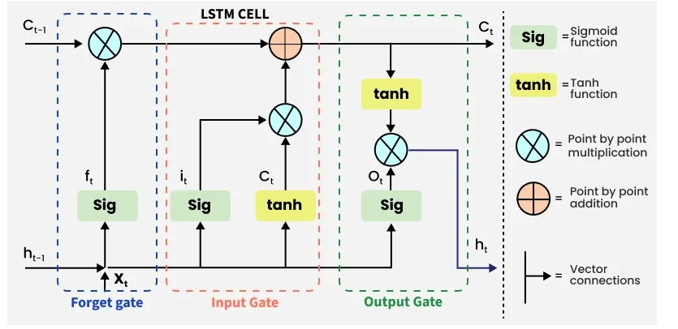

```python
from tensorflow.keras.models import Sequential
from tensorflow.keras.layers import Input, Embedding, LSTM, Dense

model = Sequential([
    Input(shape=(50,)),          # Only sequence length
    Embedding(input_dim=449, output_dim=100),
    LSTM(150),
    Dense(449, activation="softmax")
])

model.summary()
```

[output not shown]

```
Model: "sequential"
```

```
┏━━━━━━━━━━━━━━━━━━━━━━━━━━━━━━━━━┳━━━━━━━━━━━━━━━━━━━━━━━━┳━━━━━━━━━━━━━━━┓
┃ Layer (type)                    ┃ Output Shape           ┃       Param # ┃
┡━━━━━━━━━━━━━━━━━━━━━━━━━━━━━━━━━╇━━━━━━━━━━━━━━━━━━━━━━━━╇━━━━━━━━━━━━━━━┩
│ embedding (Embedding)           │ (None, 50, 100)        │        44,900 │
├─────────────────────────────────┼────────────────────────┼───────────────┤
│ lstm (LSTM)                     │ (None, 150)            │       150,600 │
├─────────────────────────────────┼────────────────────────┼───────────────┤
│ dense (Dense)                   │ (None, 449)            │        67,799 │
└─────────────────────────────────┴────────────────────────┴───────────────┘
```

```
 Total params: 263,299 (1.00 MB)
```

```
 Trainable params: 263,299 (1.00 MB)
```

```
 Non-trainable params: 0 (0.00 B)
```

[ \begin{aligned} \textbf{Input Tokens} &= \begin{bmatrix} 0 & 0 & 1\\ 0 & 1 & 2\\ 1 & 2 & 3 \end{bmatrix} \\[12pt] \textbf{Embedding Matrix }E &= \begin{bmatrix} 0.10 & 0.20 & 0.30 & 0.40 & 0.50\\ 0.60 & 0.70 & 0.80 & 0.90 & 1.00\\ 1.10 & 1.20 & 1.30 & 1.40 & 1.50\\ 1.60 & 1.70 & 1.80 & 1.90 & 2.00 \end{bmatrix} \\[12pt] \textbf{Embedded Output} &= \begin{bmatrix} \begin{bmatrix} 0.10&0.20&0.30&0.40&0.50\\ 0.10&0.20&0.30&0.40&0.50\\ 0.60&0.70&0.80&0.90&1.00 \end{bmatrix} \\[10pt] \begin{bmatrix} 0.10&0.20&0.30&0.40&0.50\\ 0.60&0.70&0.80&0.90&1.00\\ 1.10&1.20&1.30&1.40&1.50 \end{bmatrix} \\[10pt] \begin{bmatrix} 0.60&0.70&0.80&0.90&1.00\\ 1.10&1.20&1.30&1.40&1.50\\ 1.60&1.70&1.80&1.90&2.00 \end{bmatrix} \end{bmatrix} \end{aligned} ]

```python
model.compile(optimizer='adam', loss='categorical_crossentropy',metrics=['accuracy'])  # Compiling the model with Adam optimizer and categorical cross-entropy loss function. Each paragraph is separated by a new line character "\n".
```

```python
model.fit(X, Output_one_hot, epochs=100, batch_size=32)  # Training the model using the input sequences and one-hot encoded output sequences. Each paragraph is separated by a new line character "\n".
```

[output not shown]

[output not shown]

[output cut: 65 more lines]

[output not shown]

```python
test_text="architecture"

for i in range(10):
    token_text=tokenizer.texts_to_sequences([test_text])[0]
    padded_token=pad_sequences([token_text], maxlen=50)
    predicted=model.predict(padded_token)
    ind= np.argmax(predicted)
    for word,index in tokenizer.word_index.items():
        if index==ind:
            test_text=test_text+" "+word
            print(test_text)  # Printing the generated text after predicting the next word using the trained model. Each paragraph is separated by a new line character "\n".
```

```
1/1 ━━━━━━━━━━━━━━━━━━━━ 0s 110ms/step
architecture is
1/1 ━━━━━━━━━━━━━━━━━━━━ 0s 66ms/step
architecture is retained
1/1 ━━━━━━━━━━━━━━━━━━━━ 0s 51ms/step
architecture is retained by
1/1 ━━━━━━━━━━━━━━━━━━━━ 0s 56ms/step
architecture is retained by the
1/1 ━━━━━━━━━━━━━━━━━━━━ 0s 56ms/step
architecture is retained by the cells
1/1 ━━━━━━━━━━━━━━━━━━━━ 0s 59ms/step
architecture is retained by the cells and
1/1 ━━━━━━━━━━━━━━━━━━━━ 0s 107ms/step
architecture is retained by the cells and the
1/1 ━━━━━━━━━━━━━━━━━━━━ 0s 104ms/step
architecture is retained by the cells and the memory
1/1 ━━━━━━━━━━━━━━━━━━━━ 0s 68ms/step
architecture is retained by the cells and the memory manipulations
1/1 ━━━━━━━━━━━━━━━━━━━━ 0s 63ms/step
architecture is retained by the cells and the memory manipulations are
```

## At the last cell architecture find the next word and add it to the test_text variable. Then print the updated test_text variable. Each paragraph is separated by a new line character "\n".

> **This notebook is designed as an educational walkthrough that explains not only *what* happens inside an LSTM-based next-word prediction model, but also *why* each step is necessary.**